# RNN NLP Disaster Tweets

In this project, I train a couple Recurrent Neural Network (RNN) models to perform Natural Language Processing to classify tweets by relevance to real world disasters or not. This project follows the Kaggle competition found at https://www.kaggle.com/competitions/nlp-getting-started/overview.

The project data consists of about 10,000 tweets including text content, keywords, and location. Both keyword and location columns are sparse. The training data has a column containing ground truth classifications as related to disasters (1) or not (0).

## Loading Libraries and Data

For this project, I chose to use PyTorch for its fairly easy to use CUDA integration and easy to setup neural network architectures. As you can see in the output of the following cell, I'm training these models on my RTX3090 GPU. The data here isn't actually that large given that it is all text based, so I simply load in training data to a pandas dataframe. Because the `keyword` and `location` columns are very sparse, I chose to eliminate them as I do not believe they would effectively contribute to model building.

```python
import torch
import pandas as pd
import matplotlib.pyplot as plt
import numpy as np
import seaborn as sns

print(torch.cuda.get_device_name(0))

train_df = pd.read_csv('data/train.csv')
train_df = train_df.drop(columns=['keyword', 'location'])

print(train_df.head())
```

```
NVIDIA GeForce RTX 3090
   id                                               text  target
0   1  Our Deeds are the Reason of this #earthquake M...       1
1   4             Forest fire near La Ronge Sask. Canada       1
2   5  All residents asked to 'shelter in place' are ...       1
3   6  13,000 people receive #wildfires evacuation or...       1
4   7  Just got sent this photo from Ruby #Alaska as ...       1
```

## EDA

```
Number of null entities in each column:
id        0
text      0
target    0
dtype: int64
```

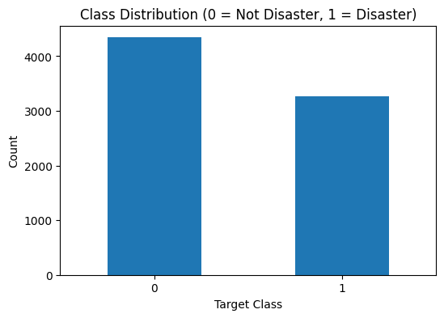

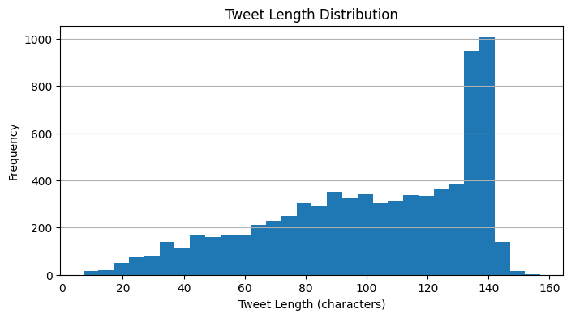

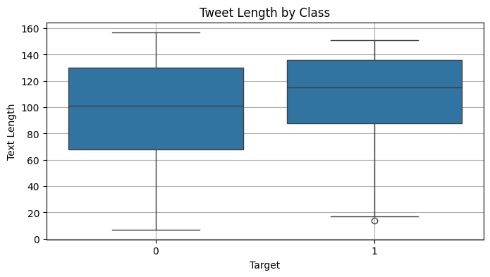

```python
print(f'\nNumber of null entities in each column:\n{train_df.isnull().sum()}')

class_counts = train_df['target'].value_counts().sort_index()

plt.figure(figsize=(6, 4))
class_counts.plot(kind='bar')
plt.title('Class Distribution (0 = Not Disaster, 1 = Disaster)')
plt.xlabel('Target Class')
plt.ylabel('Count')
plt.xticks(rotation=0)
plt.show()

train_df['text_length'] = train_df['text'].apply(len)

train_df['text_length'].hist(bins=30, figsize=(8, 4))
plt.title('Tweet Length Distribution')
plt.xlabel('Tweet Length (characters)')
plt.ylabel('Frequency')
plt.grid(axis='x')
plt.show()

plt.figure(figsize=(8, 4))
sns.boxplot(x='target', y='text_length', data=train_df)
plt.title('Tweet Length by Class')
plt.xlabel('Target')
plt.ylabel('Text Length')
plt.grid(True)
plt.show()
```

## Preprocessing/Cleaning

Here I define a function for cleaning up the text content of the tweets. The first step is forcing everything to lower case for consistency then doing a few regex substitutions/eliminations. The regex subs I made are as follows:

- I replace all URLs/links with `<URL>` in text. This is done because they are rarely helpful on their own and twitter shortens links to the format `t.co/...` which means they likely don't carry any meaning. However, the presence of a URL may indicate reference to a more serious topic such as a disaster, so I include the `<URL>` tag to maintain that presence
- I replace all @ mentions with `<USER>` in text. Similar reasoning as with URLs here. We probably won't learn anything from seeing who was mentioned, but the presence of a tag may indicate urgency in sharing information which may inform tweet classification.
- I replace all hashtag symbols with the text prefix `HASHTAG_` because it highlights the importance of the following phrase. e.g. someone writing "#earthquake" may carry more significance than simply using the word "earthquake" in a sentence.
- I null all HTML elements. I do this by parsing the `&` symbol indicating the start of an HTML element, matching entity words, and the entity end symbol `;`. I'm not sure what HTML tweets can contain if any, but I include this just in case the data scraper used to gather the data parsed special characters as HTML entities.
- I remove all punctuation. I do this because people on the internet type erratically and punctuation does not necessarily inform the gravity of a sentence (remember, this is the internet, not proper literature).
- I strip extra whitespace. This is simply done for cleanliness.

```python
import re

def clean_tweet(text):
    text = text.lower()
    text = re.sub(r'http\S+|www\S+|https\S+', '<URL>', text)
    text = re.sub(r'@\w+', '<USER>', text)
    text = re.sub(r'#(\w+)', r'HASHTAG_\1', text)
    text = re.sub(r'&\w+;', '', text)
    text = re.sub(r'[^\w\s<>]', '', text)
    text = re.sub(r'\s+', ' ', text).strip()

    return text

train_df['clean_text'] = train_df['text'].apply(clean_tweet)
```

## Preprocessing/Tokenization

I primarily use the NLTK module for tokenization. It's a pretty widely recommended package for tokenization and lemmatization of text for natural language processing tasks. `punkt` is the sentence tokenizer model NLTK uses internally for splitting text. `wordnet` is needed for lemmatization to reduce words to their base forms (e.g. "running" to "run").

My preprocessing functions `lemmatize` and `tokens_to_ids` apply the lemmatization and convert a list of tokens into integers respectively. I convert tokens not present in the vocabulary to `<UNK>` to handle Out Of Vocabulary cases. Before forming the vocabulary, I count the tokens so that I can limit the vocabulary to words that are used more frequently than others which effectively removes noise. I keep this threshold pretty low at 2 so a word only needs to appear twice in the entire dataset to get a unique ID. Vocab is initialized with `<UNK>` as mentioned for unknown tokens and `<PAD>` for padding tokens. Tokens are then converted to input IDs which are integers that act as an ID for unique tokens.

```python
import nltk
from nltk.tokenize import word_tokenize
from nltk.stem import WordNetLemmatizer
from collections import Counter
nltk.download('punkt')
nltk.download('punkt_tab')
nltk.download('wordnet')

lemmatizer = WordNetLemmatizer()

def lemmatize(tokens):
    return [lemmatizer.lemmatize(token) for token in tokens]

def tokens_to_ids(tokens, vocab):
    return [vocab.get(token, vocab['<UNK>']) for token in tokens]

train_df['tokens'] = train_df['clean_text'].apply(word_tokenize)
train_df['tokens'] = train_df['tokens'].apply(lemmatize)

token_counts = Counter(token for tokens in train_df['tokens'] for token in tokens)

special_tokens = ['<PAD>', '<UNK>']
vocab = {token: idx for idx, token in enumerate(special_tokens)}

min_frq = 2
for token, count in token_counts.items():
    if count >= min_frq and token not in vocab:
        vocab[token] = len(vocab)

for i, token in enumerate(special_tokens):
    vocab[token] = i

train_df['input_ids'] = train_df['tokens'].apply(lambda tokens: tokens_to_ids(tokens, vocab))
```

## Build Trainer Dataset

```python
from sklearn.model_selection import train_test_split
from torch.utils.data import Dataset, DataLoader

class TweetDataset(Dataset):
    def __init__(self, df):
        self.inputs = df['padded_input_ids'].tolist()
        self.labels = df['target'].tolist()

    def __len__(self):
        return len(self.inputs)

    def __getitem__(self, idx):
        return {
            'input_ids': torch.tensor(self.inputs[idx], dtype=torch.long),
            'label': torch.tensor(self.labels[idx], dtype=torch.float)
        }

def pad_sequence(seq, max_len=160, pad_value=0):
    if len(seq) < max_len:
        return seq + [pad_value] * (max_len - len(seq))
    else:
        return seq[:max_len]

train_df['padded_input_ids'] = train_df['input_ids'].apply(lambda x: pad_sequence(x, max_len=160, pad_value=vocab['<PAD>']))

training_df, val_df = train_test_split(train_df, test_size=0.1, stratify=train_df['target'], random_state=42)

train_dataset = TweetDataset(training_df)
val_dataset = TweetDataset(val_df)

train_loader = DataLoader(train_dataset, batch_size=32, shuffle=True)
val_loader = DataLoader(val_dataset, batch_size=32)
```

## Model Building

I don't have a ton of experience in MLP, so the deep learning approaches I'm trying out here are two versions of RNNs. The two models I've built here are an LSTM and a GRU architectures. I'll walk through the models one by one then compare expectations for each.

### LSTM model

The structure of this model is `[Embedding Layer -> LSTM Layer -> Attention Mechanism -> Context Vector -> Ouput]`. The embedding layer transforms token indices into dense vector representations. The padding index callout ensures that `<PAD>` tokens do not contribute to embedding gradients. Dropout in this layer adds regularization which should help generalization. I chose LSTM because it is supposed to be able to handle complex language concepts. In the LSTM layer, the optional bidirectional flag lets the model read tweets forward and backward which should improve performance on sequences regardless of grammatical structure. After the LSTM layer, I use an attention mechanism to compute scalar attention weights per time step. This basically allows the model to focus on important tokens in context. The context vector weights tokens by relevance to the classification. I then apply normalization to stabilize training and ReLU activation before final prediction from the output layer.

### GRU model

This is structured highly similarly to the LSTM model, but it uses GRU instead of LSTM. GRUs are simpler architectures that use reset and update gates instead of full LSTM cell + hidden state. The fewer parameters should make the model less prone to overfitting on small datasets. With a smaller and simple dataset like this project, it should perform comparably to the LSTM model with faster training.

```python
import torch.nn as nn

class DisasterTweetLSTM(nn.Module):
    def __init__(self, vocab_size, embedding_dim=100, hidden_dim=128, num_layers=1, bidirectional=True, dropout=0.3, pad_idx=0):
        super().__init__()

        self.embedding = nn.Embedding(vocab_size, embedding_dim, padding_idx=pad_idx)
        self.embedding_dropout = nn.Dropout(dropout)

        self.lstm = nn.LSTM(
            input_size=embedding_dim,
            hidden_size=hidden_dim,
            num_layers=num_layers,
            bidirectional=bidirectional,
            batch_first=True
        )

        self.hidden_dim = hidden_dim
        self.bidirectional = bidirectional
        self.rnn_output_dim = hidden_dim * (2 if bidirectional else 1)

        self.attn = nn.Linear(self.rnn_output_dim, 1)
        self.norm = nn.LayerNorm(self.rnn_output_dim)
        self.dropout = nn.Dropout(dropout)
        self.fc = nn.Linear(self.rnn_output_dim, 1)

    def forward(self, input_ids):
        embedded = self.embedding_dropout(self.embedding(input_ids))  # [B, T, E]

        lstm_out, _ = self.lstm(embedded)  # [B, T, H*2] if bidirectional

        attn_weights = torch.softmax(self.attn(lstm_out).squeeze(-1), dim=1)  # [B, T]

        context = torch.sum(lstm_out * attn_weights.unsqueeze(-1), dim=1)  # [B, H*2]

        x = self.norm(context)
        x = torch.relu(self.dropout(x))
        output = self.fc(x)

        return output.view(-1)

class DisasterTweetGRU(nn.Module):
    def __init__(self, vocab_size, embedding_dim=100, hidden_dim=64,
                 bidirectional=True, dropout=0.5, pad_idx=0):

        super().__init__()

        self.embedding = nn.Embedding(vocab_size, embedding_dim, padding_idx=pad_idx)
        self.embedding_dropout = nn.Dropout(dropout)

        self.gru = nn.GRU(
            input_size=embedding_dim,
            hidden_size=hidden_dim,
            num_layers=1,
            bidirectional=bidirectional,
            batch_first=True
        )

        self.hidden_dim = hidden_dim
        self.bidirectional = bidirectional
        self.rnn_output_dim = hidden_dim * (2 if bidirectional else 1)

        self.attn = nn.Linear(self.rnn_output_dim, 1)

        self.dropout = nn.Dropout(dropout)
        self.fc = nn.Linear(self.rnn_output_dim, 1)

    def forward(self, input_ids):
        embedded = self.embedding_dropout(self.embedding(input_ids))  # [B, T, E]

        rnn_out, _ = self.gru(embedded)  # [B, T, H*2] if bidirectional

        attn_weights = torch.softmax(self.attn(rnn_out).squeeze(-1), dim=1)  # [B, T]

        context = torch.sum(rnn_out * attn_weights.unsqueeze(-1), dim=1)  # [B, H*2]

        x = self.dropout(torch.relu(context))
        return self.fc(x).view(-1)  # [B]

vocab_size = len(vocab)
pad_idx = vocab['<PAD>']

model_LSTM = DisasterTweetLSTM(
    vocab_size=vocab_size,
    embedding_dim=100,
    hidden_dim=128,
    num_layers=1,
    bidirectional=True,
    dropout=0.5,
    pad_idx=pad_idx
)

model_GRU = DisasterTweetGRU(
    vocab_size=len(vocab),
    embedding_dim=100,
    hidden_dim=128,
    bidirectional=True,
    dropout=0.5,
    pad_idx=vocab['<PAD>']
)

device = torch.device('cuda' if torch.cuda.is_available() else 'cpu')
model_LSTM.to(device)
model_GRU.to(device)
```

```
DisasterTweetGRU(
  (embedding): Embedding(6237, 100, padding_idx=0)
  (embedding_dropout): Dropout(p=0.5, inplace=False)
  (gru): GRU(100, 128, batch_first=True, bidirectional=True)
  (attn): Linear(in_features=256, out_features=1, bias=True)
  (dropout): Dropout(p=0.5, inplace=False)
  (fc): Linear(in_features=256, out_features=1, bias=True)
)
```

## Model Training

This is a pretty typical training loop for a PyTorch neural network model. Salient features here include TensorBoard metric logging of some interesting epoch training parameters. These include train/validation set loss and accuracy as well as learning rate. I do have functionality built for early stopping, but I ended up leaving `patience` set at 100 epochs, so a model would need to stagnate training for 100 epochs before training actually stops early. The idea here is to prevent overfitting and more efficiently use time/resources for training, but I didn't have any issues with that only training 30 epochs.

In the next code block is where I actually run the training loops for either model. I write both LSTM and GRU metrics to my tensorboard so I can compare their training performance. I use an Adam optimizer for my model training. It combines momentum and adaptive learning rate using a standard starting point of 0.001. I also have a `weight_decay` term to apply L2 regularization which should help prevent overfitting by penalizing larger weights. The scheduler reduces learning rate by `gamma=0.9` every 3 epochs to allow smoother convergence of the models after initial exploration. The loss function I'm using is BCE loss. "WithLogits" is used because this is a binary classification task and the model outputs raw logits, not probabilities. `BCEWithLogitsLoss` combines sigmoid activation with binary cross-entropy loss.

```python
from torch.utils.tensorboard import SummaryWriter
from tqdm import tqdm
import torch.nn.functional as F

def train_model(model, train_loader, val_loader, optimizer, criterion, scheduler=None, n_epochs=5, log_dir='runs/experiment'):
    writer = SummaryWriter(log_dir=log_dir)
    global_step = 0

    best_val_acc = 0
    patience = 100
    epochs_no_improve = 0

    for epoch in range(n_epochs):
        model.train()
        train_loss = 0
        train_acc = 0

        print(f'\nEpoch {epoch+1}/{n_epochs}')
        train_iter = tqdm(train_loader, desc='Training', leave=False)

        for batch in train_iter:
            input_ids = batch['input_ids'].to(torch.device('cuda'))
            labels = batch['label'].to(torch.device('cuda'))

            optimizer.zero_grad()
            preds = model(input_ids)
            loss = criterion(preds, labels)
            loss.backward()
            optimizer.step()

            acc = binary_accuracy(preds, labels)
            train_loss += loss.item()
            train_acc += acc.item()
            global_step += 1

            train_iter.set_postfix(loss=loss.item(), acc=acc.item())

        avg_train_loss = train_loss / len(train_loader)
        avg_train_acc = train_acc / len(train_loader)

        # Validation
        model.eval()
        val_loss = 0
        val_acc = 0

        with torch.no_grad():
            val_iter = tqdm(val_loader, desc='Validation', leave=False)
            for batch in val_iter:
                input_ids = batch['input_ids'].to(torch.device('cuda'))
                labels = batch['label'].to(torch.device('cuda'))

                preds = model(input_ids)
                loss = criterion(preds, labels)
                acc = binary_accuracy(preds, labels)

                val_loss += loss.item()
                val_acc += acc.item()

        avg_val_loss = val_loss / len(val_loader)
        avg_val_acc = val_acc / len(val_loader)

        # Log to TensorBoard
        writer.add_scalar('Loss/train', avg_train_loss, epoch)
        writer.add_scalar('Loss/val', avg_val_loss, epoch)
        writer.add_scalar('Accuracy/train', avg_train_acc, epoch)
        writer.add_scalar('Accuracy/val', avg_val_acc, epoch)
        writer.add_scalar('Learning Rate', optimizer.param_groups[0]['lr'], epoch)

        if scheduler is not None:
            scheduler.step()

        # Epoch summary
        print(f'[Epoch {epoch+1}]\n'
              f'Train Loss: {avg_train_loss:.4f}, Train Acc: {avg_train_acc:.4f}\n'
              f'Val Loss:   {avg_val_loss:.4f}, Val Acc:   {avg_val_acc:.4f}')

        if avg_val_acc > best_val_acc:
            best_val_acc = avg_val_acc
            torch.save(model.state_dict(), 'best_model.pt')
            epochs_no_improve = 0
        else:
            epochs_no_improve += 1
            if epochs_no_improve >= patience:
                print('Stopping early.')
                break

    writer.close()

def binary_accuracy(preds, y):
    probs = torch.sigmoid(preds)
    rounded = torch.round(probs)
    correct = (rounded == y).float()

    return correct.sum() / len(correct)
```

```python
import os

optimizer_LSTM = torch.optim.Adam(model_LSTM.parameters(), lr=1e-3, weight_decay=1e-5)
scheduler_LSTM = torch.optim.lr_scheduler.StepLR(optimizer_LSTM, step_size=3, gamma=0.9)
optimizer_GRU = torch.optim.Adam(model_GRU.parameters(), lr=1e-3, weight_decay=1e-5)
scheduler_GRU = torch.optim.lr_scheduler.StepLR(optimizer_GRU, step_size=3, gamma=0.9)
criterion = nn.BCEWithLogitsLoss()

n_subfolders = sum(os.path.isdir(os.path.join('runs', d)) for d in os.listdir('runs')) // 2
lstm_dir = f'runs/disaster_lstm{n_subfolders}'
gru_dir = f'runs/disaster_gru{n_subfolders}'

train_model(model_LSTM, train_loader, val_loader, optimizer_LSTM, criterion, scheduler=scheduler_LSTM, n_epochs=30, log_dir=lstm_dir)
train_model(model_GRU, train_loader, val_loader, optimizer_GRU, criterion, scheduler=scheduler_GRU, n_epochs=30, log_dir=gru_dir)
```

```
[Epoch 1]
Train Loss: 0.6518, Train Acc: 0.6233
Val Loss:   0.5822, Val Acc:   0.6936
```

```
[Epoch 2]
Train Loss: 0.5637, Train Acc: 0.7223
Val Loss:   0.5156, Val Acc:   0.7502
```

```
[Epoch 3]
Train Loss: 0.5075, Train Acc: 0.7599
Val Loss:   0.5030, Val Acc:   0.7580
```

```
[Epoch 4]
Train Loss: 0.4705, Train Acc: 0.7871
Val Loss:   0.4895, Val Acc:   0.7700
```

```
[Epoch 5]
Train Loss: 0.4458, Train Acc: 0.7993
Val Loss:   0.4854, Val Acc:   0.7778
```

```
[Epoch 6]
Train Loss: 0.4282, Train Acc: 0.8138
Val Loss:   0.4704, Val Acc:   0.7739
```

```
[Epoch 7]
Train Loss: 0.4033, Train Acc: 0.8247
Val Loss:   0.4829, Val Acc:   0.7739
```

```
[Epoch 8]
Train Loss: 0.3793, Train Acc: 0.8403
Val Loss:   0.5060, Val Acc:   0.7791
```

```
[Epoch 9]
Train Loss: 0.3798, Train Acc: 0.8359
Val Loss:   0.4767, Val Acc:   0.7778
```

```
[Epoch 10]
Train Loss: 0.3574, Train Acc: 0.8493
Val Loss:   0.4983, Val Acc:   0.7834
```

```
[Epoch 11]
Train Loss: 0.3366, Train Acc: 0.8560
Val Loss:   0.4893, Val Acc:   0.7778
```

```
[Epoch 12]
Train Loss: 0.3266, Train Acc: 0.8673
Val Loss:   0.4900, Val Acc:   0.7700
```

```
[Epoch 13]
Train Loss: 0.3221, Train Acc: 0.8694
Val Loss:   0.5325, Val Acc:   0.7847
```

```
[Epoch 14]
Train Loss: 0.3014, Train Acc: 0.8757
Val Loss:   0.5401, Val Acc:   0.7860
```

```
[Epoch 15]
Train Loss: 0.2915, Train Acc: 0.8828
Val Loss:   0.5552, Val Acc:   0.7804
```

```
[Epoch 16]
Train Loss: 0.2827, Train Acc: 0.8886
Val Loss:   0.5781, Val Acc:   0.7674
```

```
[Epoch 17]
Train Loss: 0.2755, Train Acc: 0.8901
Val Loss:   0.5747, Val Acc:   0.7713
```

```
[Epoch 18]
Train Loss: 0.2662, Train Acc: 0.8948
Val Loss:   0.5933, Val Acc:   0.7713
```

```
[Epoch 19]
Train Loss: 0.2477, Train Acc: 0.8993
Val Loss:   0.6067, Val Acc:   0.7726
```

```
[Epoch 20]
Train Loss: 0.2455, Train Acc: 0.9031
Val Loss:   0.6195, Val Acc:   0.7765
```

```
[Epoch 21]
Train Loss: 0.2290, Train Acc: 0.9105
Val Loss:   0.6469, Val Acc:   0.7726
```

```
[Epoch 22]
Train Loss: 0.2362, Train Acc: 0.9039
Val Loss:   0.6040, Val Acc:   0.7703
```

```
[Epoch 23]
Train Loss: 0.2248, Train Acc: 0.9135
Val Loss:   0.6484, Val Acc:   0.7742
```

```
[Epoch 24]
Train Loss: 0.2318, Train Acc: 0.9085
Val Loss:   0.6392, Val Acc:   0.7755
```

```
[Epoch 25]
Train Loss: 0.2079, Train Acc: 0.9166
Val Loss:   0.6635, Val Acc:   0.7700
```

```
[Epoch 26]
Train Loss: 0.2085, Train Acc: 0.9221
Val Loss:   0.6955, Val Acc:   0.7687
```

```
[Epoch 27]
Train Loss: 0.1919, Train Acc: 0.9243
Val Loss:   0.6892, Val Acc:   0.7713
```

```
[Epoch 28]
Train Loss: 0.2045, Train Acc: 0.9176
Val Loss:   0.6689, Val Acc:   0.7713
```

```
[Epoch 29]
Train Loss: 0.1877, Train Acc: 0.9295
Val Loss:   0.7040, Val Acc:   0.7755
```

```
[Epoch 30]
Train Loss: 0.1832, Train Acc: 0.9295
Val Loss:   0.7102, Val Acc:   0.7716
```

```
[Epoch 1]
Train Loss: 0.6420, Train Acc: 0.6298
Val Loss:   0.5744, Val Acc:   0.7182
```

```
[Epoch 2]
Train Loss: 0.5638, Train Acc: 0.7204
Val Loss:   0.5642, Val Acc:   0.7153
```

```
[Epoch 3]
Train Loss: 0.5244, Train Acc: 0.7493
Val Loss:   0.4927, Val Acc:   0.7638
```

```
[Epoch 4]
Train Loss: 0.4867, Train Acc: 0.7760
Val Loss:   0.4861, Val Acc:   0.7622
```

```
[Epoch 5]
Train Loss: 0.4529, Train Acc: 0.7954
Val Loss:   0.4879, Val Acc:   0.7765
```

```
[Epoch 6]
Train Loss: 0.4249, Train Acc: 0.8099
Val Loss:   0.4554, Val Acc:   0.7948
```

```
[Epoch 7]
Train Loss: 0.4073, Train Acc: 0.8222
Val Loss:   0.4877, Val Acc:   0.7922
```

```
[Epoch 8]
Train Loss: 0.3899, Train Acc: 0.8325
Val Loss:   0.4739, Val Acc:   0.7870
```

```
[Epoch 9]
Train Loss: 0.3688, Train Acc: 0.8399
Val Loss:   0.4799, Val Acc:   0.8016
```

```
[Epoch 10]
Train Loss: 0.3488, Train Acc: 0.8522
Val Loss:   0.5145, Val Acc:   0.7922
```

```
[Epoch 11]
Train Loss: 0.3358, Train Acc: 0.8548
Val Loss:   0.4992, Val Acc:   0.7883
```

```
[Epoch 12]
Train Loss: 0.3260, Train Acc: 0.8616
Val Loss:   0.5249, Val Acc:   0.7807
```

```
[Epoch 13]
Train Loss: 0.3087, Train Acc: 0.8685
Val Loss:   0.5421, Val Acc:   0.7818
```

```
[Epoch 14]
Train Loss: 0.3021, Train Acc: 0.8751
Val Loss:   0.5396, Val Acc:   0.7922
```

```
[Epoch 15]
Train Loss: 0.2783, Train Acc: 0.8848
Val Loss:   0.5897, Val Acc:   0.7990
```

```
[Epoch 16]
Train Loss: 0.2798, Train Acc: 0.8824
Val Loss:   0.5730, Val Acc:   0.7886
```

```
[Epoch 17]
Train Loss: 0.2745, Train Acc: 0.8890
Val Loss:   0.5820, Val Acc:   0.7899
```

```
[Epoch 18]
Train Loss: 0.2607, Train Acc: 0.8919
Val Loss:   0.5688, Val Acc:   0.7818
```

```
[Epoch 19]
Train Loss: 0.2592, Train Acc: 0.8917
Val Loss:   0.5696, Val Acc:   0.7925
```

```
[Epoch 20]
Train Loss: 0.2650, Train Acc: 0.8923
Val Loss:   0.5739, Val Acc:   0.7867
```

```
[Epoch 21]
Train Loss: 0.2487, Train Acc: 0.9008
Val Loss:   0.6235, Val Acc:   0.7870
```

```
[Epoch 22]
Train Loss: 0.2341, Train Acc: 0.9027
Val Loss:   0.6383, Val Acc:   0.7815
```

```
[Epoch 23]
Train Loss: 0.2285, Train Acc: 0.9028
Val Loss:   0.6701, Val Acc:   0.7951
```

```
[Epoch 24]
Train Loss: 0.2162, Train Acc: 0.9140
Val Loss:   0.6964, Val Acc:   0.7899
```

```
[Epoch 25]
Train Loss: 0.2073, Train Acc: 0.9156
Val Loss:   0.7086, Val Acc:   0.7899
```

```
[Epoch 26]
Train Loss: 0.1987, Train Acc: 0.9180
Val Loss:   0.7096, Val Acc:   0.7768
```

```
[Epoch 27]
Train Loss: 0.2012, Train Acc: 0.9195
Val Loss:   0.6898, Val Acc:   0.7765
```

```
[Epoch 28]
Train Loss: 0.1981, Train Acc: 0.9201
Val Loss:   0.7404, Val Acc:   0.7807
```

```
[Epoch 29]
Train Loss: 0.1905, Train Acc: 0.9192
Val Loss:   0.7370, Val Acc:   0.7873
```

```
[Epoch 30]
Train Loss: 0.1911, Train Acc: 0.9227
Val Loss:   0.7275, Val Acc:   0.7765
```

## Model Training Evaluation

Below I show the screenshot of my training evaluation graphs. In orange is the GRU model. and in grey is the LSTM model. I was actually quite surprised that they performed nearly identically. The LSTM had slightly worse validation accuracy despite nearly identical training accuracy, so that may indicate a slightly higher degree of overfitting. Otherwise, loss across both validation and training sets were almost identical. I will note, loss actually increased for both GRU and LSTM models over the 30 epochs which isn't great. It's interesting that this happens despite the decreasing learning rate. The increasing loss across both models might indicate the need for stronger regularization or a change in the architecture's implementation of attention weighting or perhaps application of pretrained embeddings or a transformer encoder. There are all areas for future improvement.

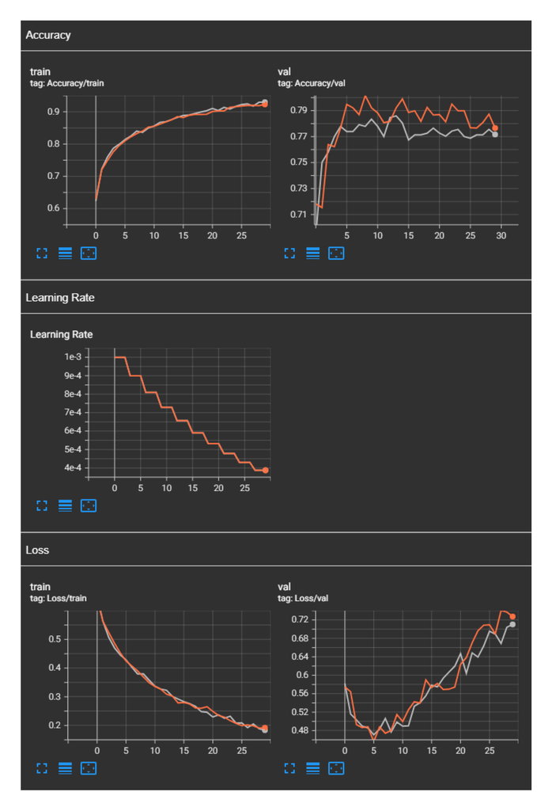

```python
import matplotlib.image as mpimg

img = mpimg.imread('training_eval.png')

imgplot = plt.imshow(img)
plt.axis('off')
plt.gcf().set_dpi(600)
plt.show()
```

## Test Set Evaluation/Submission

The following cell loads the test data and runs it through each of the models saving classifications to submission CSVs for each.

Final scores (as seen in the image output by the next cell down):

- LSTM Model: 77.23%
- GRU Model: 76.68%

```python
test_df = pd.read_csv('data/test.csv')
test_df['dropna_text'] = test_df['text'].str.lower().fillna('')
test_df['clean_text'] = test_df['dropna_text'].apply(clean_tweet)
test_df['tokens'] = test_df['clean_text'].apply(word_tokenize)
test_df['input_ids'] = test_df['tokens'].apply(lambda tokens: [vocab.get(token, vocab['<UNK>']) for token in tokens])
test_df['padded_input_ids'] = test_df['input_ids'].apply(lambda x: x[:160] + [vocab['<PAD>']] * max(0, 160 - len(x)))

class TestTweetDataset(Dataset):
    def __init__(self, df):
        self.inputs = df['padded_input_ids'].tolist()

    def __len__(self):
        return len(self.inputs)

    def __getitem__(self, idx):
        return torch.tensor(self.inputs[idx], dtype=torch.long)

test_dataset = TestTweetDataset(test_df)
test_loader = DataLoader(test_dataset, batch_size=32)

model_LSTM.eval()
all_preds = []

with torch.no_grad():
    for batch in test_loader:
        input_ids = batch.to(device)
        logits = model_LSTM(input_ids)
        probs = torch.sigmoid(logits)
        preds = torch.round(probs)
        all_preds.extend(preds.cpu().numpy().astype(int))

submission = pd.DataFrame({
    'id': test_df['id'],
    'target': all_preds
})

submission.to_csv('submission_LSTM.csv', index=False)

model_GRU.eval()
all_preds = []

with torch.no_grad():
    for batch in test_loader:
        input_ids = batch.to(device)
        logits = model_GRU(input_ids)
        probs = torch.sigmoid(logits)
        preds = torch.round(probs)
        all_preds.extend(preds.cpu().numpy().astype(int))

submission = pd.DataFrame({
    'id': test_df['id'],
    'target': all_preds
})

submission.to_csv('submission_GRU.csv', index=False)
```

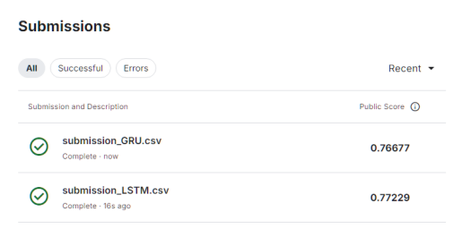

```python
img = mpimg.imread('scores.png')

imgplot = plt.imshow(img)
plt.axis('off')
plt.show()
```

## Conclusions

In this project, I developed and compared two deep learning models—an LSTM with attention and a GRU with attention—to classify whether tweets describe real disaster events. The preprocessing pipeline included lowercasing, tokenization, lemmatization, and conversion to padded token IDs, with out-of-vocabulary handling and a vocabulary built using a frequency threshold. Both models used learned embeddings, self-attention mechanisms, and dropout for regularization, and were trained using binary cross-entropy loss with logits, Adam optimization, and a learning rate scheduler.

The GRU model demonstrated slightly faster convergence and slightly better generalization during training, but on the final test submission, the LSTM outperformed the GRU by a small margin (LSTM: 0.77229, GRU: 0.76677 accuracy). This suggests that while GRUs might be more computationally efficient and generalize well in training, the LSTM’s capacity to retain long-term dependencies may offer a slight edge in nuanced real-world predictions.

Several strategies proved useful when I was iterating on these models:

- Adding attention significantly improved performance by allowing the model to focus on key tokens within tweets.
- Dropout and L2 regularization (via weight decay) helped mitigate overfitting.
- A learning rate scheduler (StepLR) helped with stable convergence.

However, some interventions—such as lemmatization, expanded preprocessing (e.g., hashtag normalization, emoji handling), and tighter regularization—had minimal or inconsistent impact on validation accuracy. Performance plateaued around 78–79%, indicating a possible representation ceiling with the current architecture and dataset.

Future things I might try:

- Incorporating pretrained word embeddings such as GloVe to bring in external semantic knowledge (this feels a bit like cheating).
- Exploring recommended models I've read about such as transformer-based models like DistilBERT, which have shown good performance on short-text classification tasks.
- Performing error analysis on misclassified tweets to identify recurring patterns, such as sarcasm or domain-specific vocabulary.
- Using model ensembling to combine strengths of both LSTM and GRU-based models.

Overall, this project demonstrated that traditional RNN-based architectures, when augmented with attention and regularization, are capable of achieving strong results on tweet classification, but more modern language models may be needed to push performance further.